# FML_Assignment_4

#### Question(C) Is there a pattern in the clusters with respect to the numerical variables (10 to 12)? (those not used in forming the clusters)

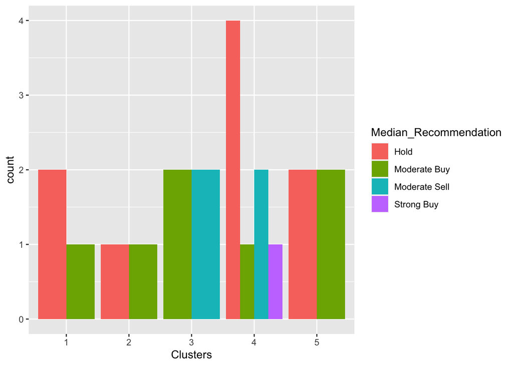

```r
Pharma <- data[12:14] %>% mutate(Clusters=k_5$cluster)
ggplot(Pharma, mapping = aes(factor(Clusters), fill =Median_Recommendation))+geom_bar(position='dodge')+labs(x ='Clusters')
```

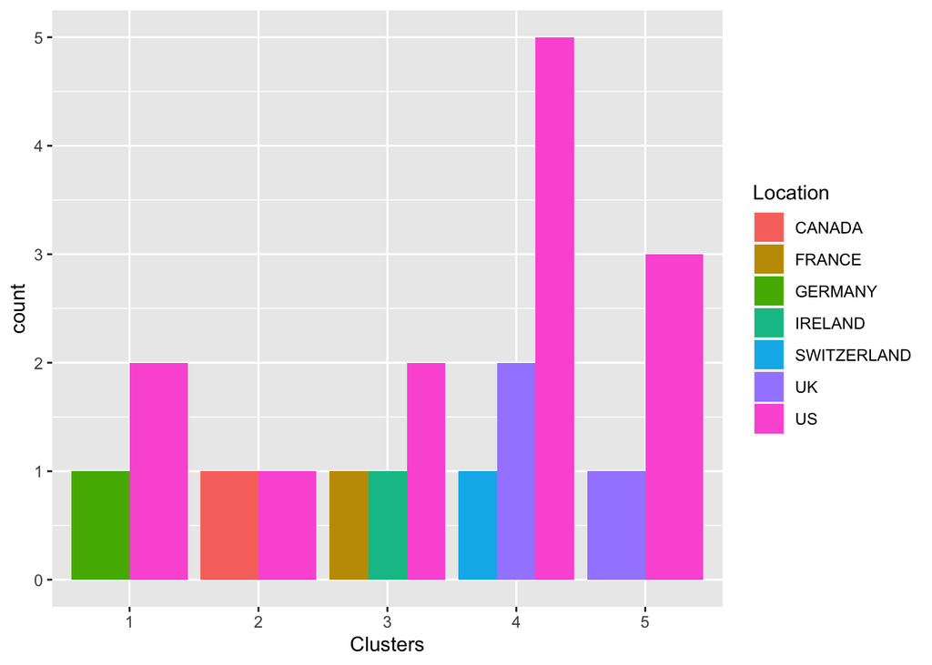

```r
ggplot(Pharma, mapping = aes(factor(Clusters),fill = Location))+geom_bar(position = 'dodge')+labs(x ='Clusters')
```

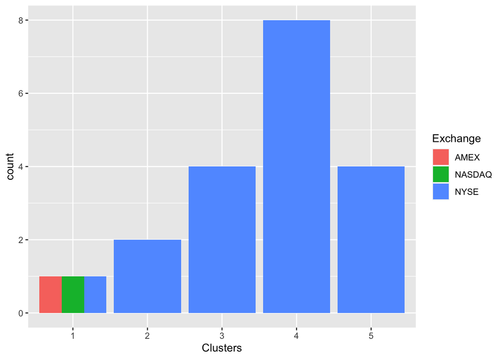

```r
ggplot(Pharma, mapping = aes(factor(Clusters),fill = Exchange))+geom_bar(position = 'dodge')+labs(x ='Clusters')
```

#### Interpretation :

#### The clusters from the graphs above show a slight pattern that we can observe #### The businesses in cluster 1 are evenly distributed across the AMEX, NASDAQ, and NYSE, but it has distinct Hold and Moderate Buy medians and a different count from the US and Germany.

#### The medians for holds and moderate purchases are distributed similarly in Cluster 2.

#### The NYSE lists stocks from both the US and Canada.

#### Cluster 3 differs from Cluster in count, but its Moderate Buy and Sell medians are comparable.

#### The NYSE lists France, Ireland, and the US.

#### Hold, Moderate Buy, Moderate Sell, and Strong Buy options are available in Cluster 4.

#### The hold’s median is the highest. They are listed on the NYSE and are citizens of the United States, the United Kingdom, and Switzerland.

#### Cluster 5 is spread across

#### countries, including the US and the UK, and is listed on the NYSE. It also has the same hold and median purchase values.

#### Question(D) Provide an appropriate name for each cluster using any or all of the variables in the dataset.

```r
#Naming clusters
#After performing cluster analysis on the pharmaceutical firms dataset,Assigning  descriptive names to each cluster based on their characteristics.

#Cluster 1 :- Buy Cluster
#Cluster 2 :- Sceptical Cluster
#Cluster 3 :- Moderate Buy Cluster
#Cluster 4 :- Hold Cluster
#Cluster 5 :- High Hold Cluster
```